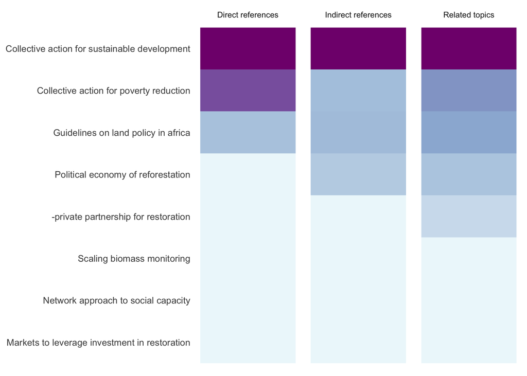

**Collective action for poverty reduction**

1. Past and present land tenure policies have tended to discriminate against the communal interests of pastoralist communities, and the federal governments policy does not yet accommodate both customary modes of communal land use and emerging trends toward privatization. Collective action on a local scale is insufficient to counter the unmaking of the commons. It needs to be complemented by a land tenure policy that ensures the rights of communal users. Property rights to land and its multiple resources are central in defining incentives for collective action. Neither clans nor customary rule systems are adequate to fully adapt to changed environmental and social conditions. Nor has the state yet found a constructive role in the encounter with pastoralism and clan societies. A redefinition of this relationship is urgently needed. **18**
2. De facto privatization and individualization provide some clan members with secure access to resources and additional income, but potentially exclude others. While inter-clan negotiation may entail access to pasture commons, asset-poor households may fail to capture the associated benefit streams when water access is privatized and prohibitively priced. In that case, clan members may have endowments to some commons resources like pasture, but will not enjoy the entitlement to actual benefit streams because of exclusion from others like water. **18**
3. Averting state coercion the coercive expropriation of pastoral land has slowed since 1991, and afar pastoralists have regained some of their lost rights over their traditional land. However, the current national policies are not immune from the anti-pastoral sentiment. The 2005 national land use proclamation declares that communal rural land holdings may be converted to private holdings if the government finds it necessary. There is also a plan to expand irrigated land in the awash basin. Implementation of such a plan would require evicting pastoralists. Current experiences in non-pastoral areas show that undervaluation of land, large variance between what investors pay and what evicts receive, and failure of evicts to start new livelihoods are critical problems associated with the expansion of investments in rural areas of ethiopia. These problems are attributable to a lack of effective institutions and appropriate governance structures, including lack of clear guidelines on land valuation, marginalization of landholders in the process of land transfers, and a weak organizational setup to administer the transformation process. **15**
4. In eastern ethiopia, property rights regimes to pastoral resources have undergone dynamic changes, and these changes affect incentives for and benefits from collective action to manage common property resources and the different technologies and artifacts that make benefit streams available from water and pasture use. These changes have further differentiated socioeconomic livelihoods and capabilities within agro-pastoralist society. The trend is toward privatizing and individualizing benefit streams to resources. Rights to those benefits are individualized, but duties to maintain commons resources are externalized. The impact of this on regulating access to the pastoral commons has disturbed reciprocal resource-sharing arrangements between clans, induced inter-clan disputes, and restricted mobility. **18**
5. The move to construct private cisterns was a turning point in collective action for joint management of communal water resources. Wealthier clan members did not have incentives to contribute to the maintenance of communal water points. In effect, maintenance was relegated to politically or economically less powerful clan members. This transformation of intra-clan responsibilities and duties effectively changed the genealogical and social networks as well as the tight connections between rights and duties that were inherent in customary rules. **18**

**Collective action for sustainable development**